# DATA 2401 Group Project

Lauren Duvall, Shikyna William, Thomas Linden

2025-04-17

# **Exploring Potential Influencers of Math Student Performance**

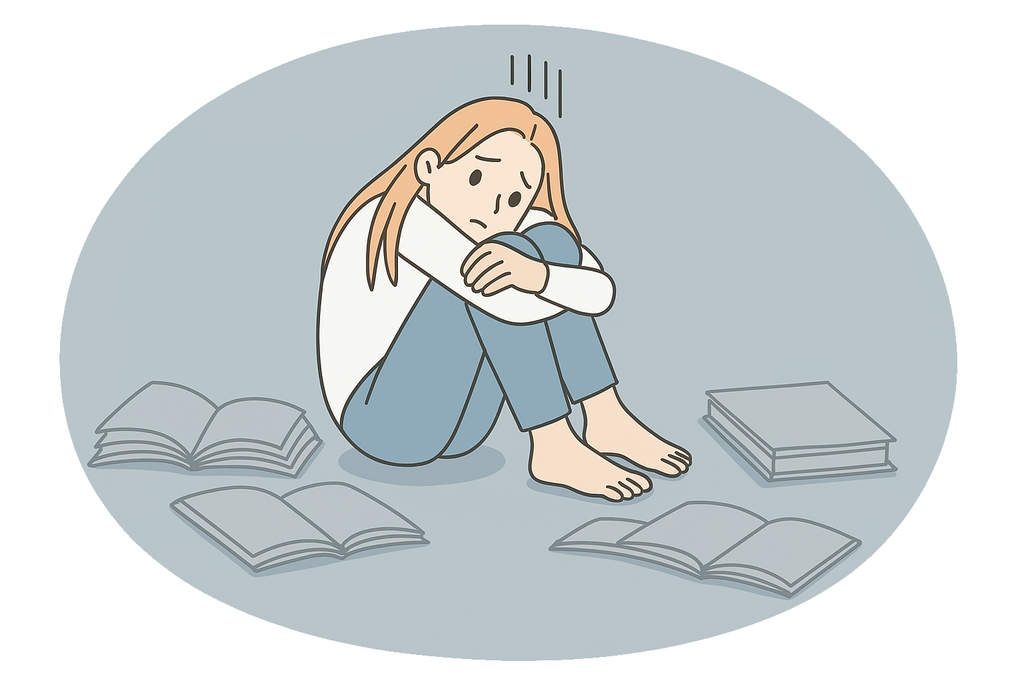

## Introduction

This project dives deep into a dataset named from the [UCI Machine Learning Repository](https://www.kaggle.com/datasets/adilshamim8/math-students/data), which contains data on student performance in math programs at two Portuguese secondary schools. The data was collected using school reports and student questionaires and features academic, personal, and social aspects of a student’s life.

### Why Is This Interesting?

This dataset is interesting because it shows how multiple aspects of a student’s life correlate to their scores in school. In addition, the features (G1, G2, G3) represent period 1-3 of a school year (similar to a midterm in the United States being period 1/2 and finals being 2/2.) This is interesting because you can see if a student’s score decreases over time (falling behind gradually due to external factors) or maintains a consistent grade throughout the year- these features also allow a ML model to predict G3 based off G1, G2, and the other external factors.

## Objective

Our goal is to determine factors that have the most significant impact on student performance in the math program. In addition, we hope to discover factors which may seem influential based on intuition but prove otherwise after analyzing the data.

### Categories Analyzed

#### Logistics & School Choice

- traveltime — Home to school travel time (1 to 4 scale)
- reason — Reason for choosing the school (home, reputation, course, other)

#### School & Demographics

- Do students from different schools (GP vs MS) show significant differences in final performance (G3)?
- Is there an interaction between romantic relationships and gender on academic performance?

#### Family Background

- Do students with higher parental education (Medu/Fedu) perform better in math?
- Does having family support at home (famsup) help students perform better in school?

#### Academic Support & Study Habits

- Which factors (e.g., studytime, failures, goout, health) are the most predictive of final grades (G3)?
- Does weekly study time affect performance consistently across all three grading periods (G1, G2, G3)?

#### Activities & Social Life

- Do students who have a romantic relationship perform differently from those who don’t?
- Is there a relationship between students’ participation in extracurricular activities and their number of absences?

#### Health & Lifestyle

- What is the relationship between alcohol consumption (weekdays Dalc vs weekends Walc) and final grades?
- Do students with internet access and more activities have more school absences than others?

#### Academic Performance

- Do students who fail more subjects in the past continue to perform poorly in current grading periods?
- How consistent are students’ performances across G1, G2, and G3? Is there improvement or decline over time?

## Load Packages

We utilized the following libraries:

- **dplyr** for basic data manipulation.
- **DT / kableExtra** to display the data tables.
- **tidyr** for table pivots.
- **ggplot2** for creating plots.
- **plotly** to add interactivity to the plots.
- **GGally** for ggparacord()’s parallel coordinates chart.
- **ggridges** for ridge plot.
- **patchwork** for side by side plots.

## Data Cleaning

Using transmute(), we changed character columns to factors, and those with levels have been ordered. We used transmute instead of mutate so original columns would drop and there would be no redundant data. There are no missing values in the dataset which was confirmed with sum(is.na()).

| school | sex | age | address | fam_size | parental_stat | mom_edu | dad_edu | mom_job | dad_job | attend_reason | guardian | travel_time | study_time | failures | school_support | family_support | extra_paid_classes | activities | nursery_school | pursue_higher_edu | internet_use | romantic | family_relationship | free_time | go_out_w_friends | workday_alcohol | weekend_alcohol | health | absences | … |
| --- | --- | --- | --- | --- | --- | --- | --- | --- | --- | --- | --- | --- | --- | --- | --- | --- | --- | --- | --- | --- | --- | --- | --- | --- | --- | --- | --- | --- | --- | --- |
| GP | F | 18 | U | GT3 | A | 4 | 4 | at_home | teacher | course | mother | 2 | 2 | 0 | yes | no | no | no | yes | yes | no | no | 4 | 3 | 4 | 1 | 1 | 3 | 6 | … |
| GP | F | 17 | U | GT3 | T | 1 | 1 | at_home | other | course | father | 1 | 2 | 0 | no | yes | no | no | no | yes | yes | no | 5 | 3 | 3 | 1 | 1 | 3 | 4 | … |
| GP | F | 15 | U | LE3 | T | 1 | 1 | at_home | other | other | mother | 1 | 2 | 3 | yes | no | yes | no | yes | yes | yes | no | 4 | 3 | 2 | 2 | 3 | 3 | 10 | … |
| GP | F | 15 | U | GT3 | T | 4 | 2 | health | services | home | mother | 1 | 3 | 0 | no | yes | yes | yes | yes | yes | yes | yes | 3 | 2 | 2 | 1 | 1 | 5 | 2 | … |
| GP | F | 16 | U | GT3 | T | 3 | 3 | other | other | home | father | 1 | 2 | 0 | no | yes | yes | no | yes | yes | no | no | 4 | 3 | 2 | 1 | 2 | 5 | 4 | … |
| GP | M | 16 | U | LE3 | T | 4 | 3 | services | other | reputation | mother | 1 | 2 | 0 | no | yes | yes | yes | yes | yes | yes | no | 5 | 4 | 2 | 1 | 2 | 5 | 10 | … |
| GP | M | 16 | U | LE3 | T | 2 | 2 | other | other | home | mother | 1 | 2 | 0 | no | no | no | no | yes | yes | yes | no | 4 | 4 | 4 | 1 | 1 | 3 | 0 | … |
| GP | F | 17 | U | GT3 | A | 4 | 4 | other | teacher | home | mother | 2 | 2 | 0 | yes | yes | no | no | yes | yes | no | no | 4 | 1 | 4 | 1 | 1 | 1 | 6 | … |
| GP | M | 15 | U | LE3 | A | 3 | 2 | services | other | home | mother | 1 | 2 | 0 | no | yes | yes | no | yes | yes | yes | no | 4 | 2 | 2 | 1 | 1 | 1 | 0 | … |
| GP | M | 15 | U | GT3 | T | 3 | 4 | other | other | home | mother | 1 | 2 | 0 | no | yes | yes | yes | yes | yes | yes | no | 5 | 5 | 1 | 1 | 1 | 5 | 0 | … |

[output cut: 389 more lines]

The “DT” package is an R interface to the Javascript library “DataTables”. With help from the documentation, we enabled horizontal scrolling, auto column widths, and centered values within each column via a list of lists.

- **columnDefs:** passed to JS as an array of objects (list of lists). Why? Each inner list can apply a different css class or apply to a different set of columns. Options, options, options!
- **dt-center:** applies the center data css class
- **targets:** applies settings to all columns

## Exploratory Data Analysis

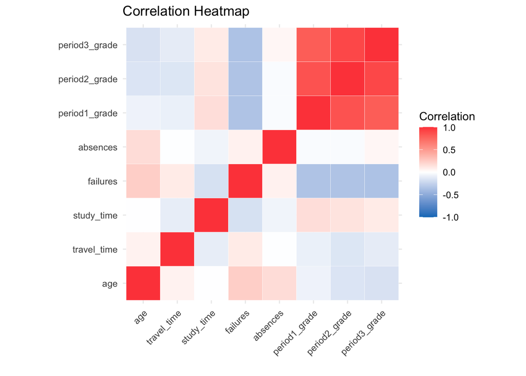

A quick way for us to explore the data was via correlation heatmap. Strong positive correlations are set to red, while strongly negative to blue. This plot was used as a starting point for the questions we wanted answered, as well as basic plots that could then benefit from a third degree of comparison (factors).

**Intuitive relationships:**

- Grades from all three periods are strongly positively correlated.
- Grades are negatively correlated with the number of failures.

**Some relationships to look into more:**

- Travel time is inversely proportional to study time.
- Number of failures is positively correlated to travel time; negatively correlated with study time.

**Features not in the correlation heatmap: (Potential 3rd Degrees of Comparison)**

- All factor features, including but not limited to: parental, financial, and social details.

## Academic Support & Study Habits

### Which factors are most predictive of final grades?

Minimal Impact: ∆ < 1

| Factor | Level | Factor Avg | Difference |
| --- | --- | --- | --- |
| school | GP | 10.49 | 0.11 |
| school | MS | 9.62 | -0.76 |
| sex | F | 9.97 | -0.41 |
| sex | M | 10.83 | 0.45 |
| address | R | 9.51 | -0.87 |
| address | U | 10.63 | 0.25 |
| fam_size | GT3 | 10.13 | -0.25 |
| fam_size | LE3 | 11.00 | 0.62 |
| parental_stat | A | 11.20 | 0.81 |
| parental_stat | T | 10.29 | -0.09 |
| mom_edu | 2 | 9.73 | -0.65 |
| mom_edu | 3 | 10.30 | -0.08 |
| dad_edu | 2 | 10.26 | -0.12 |
| dad_edu | 3 | 10.66 | 0.28 |
| dad_edu | 4 | 11.19 | 0.81 |
| mom_job | other | 9.82 | -0.56 |
| mom_job | services | 11.02 | 0.64 |
| mom_job | teacher | 10.79 | 0.41 |
| dad_job | at_home | 10.00 | -0.38 |
| dad_job | other | 10.18 | -0.20 |
| dad_job | services | 10.24 | -0.14 |
| attend_reason | course | 9.78 | -0.60 |
| attend_reason | home | 10.26 | -0.12 |
| attend_reason | other | 11.17 | 0.79 |
| attend_reason | reputation | 11.07 | 0.68 |
| guardian | father | 10.69 | 0.31 |
| guardian | mother | 10.43 | 0.05 |
| school_support | no | 10.52 | 0.14 |
| school_support | yes | 9.43 | -0.95 |
| family_support | no | 10.55 | 0.17 |
| family_support | yes | 10.27 | -0.11 |
| extra_paid_classes | no | 9.93 | -0.45 |
| extra_paid_classes | yes | 10.92 | 0.54 |
| activities | no | 10.27 | -0.11 |
| activities | yes | 10.49 | 0.11 |
| nursery_school | no | 9.81 | -0.57 |
| nursery_school | yes | 10.54 | 0.15 |
| pursue_higher_edu | yes | 10.57 | 0.19 |
| internet_use | yes | 10.62 | 0.24 |
| romantic | no | 10.78 | 0.40 |
| romantic | yes | 9.58 | -0.81 |
| family_relationship | 1 | 10.62 | 0.24 |
| family_relationship | 2 | 9.89 | -0.49 |
| family_relationship | 3 | 10.04 | -0.34 |
| family_relationship | 4 | 10.36 | -0.02 |
| family_relationship | 5 | 10.69 | 0.31 |
| free_time | 1 | 9.84 | -0.54 |
| free_time | 3 | 9.71 | -0.67 |
| free_time | 4 | 10.43 | 0.05 |
| free_time | 5 | 11.30 | 0.92 |
| go_out_w_friends | 1 | 9.87 | -0.51 |
| go_out_w_friends | 2 | 11.04 | 0.66 |
| go_out_w_friends | 3 | 10.96 | 0.58 |
| go_out_w_friends | 4 | 9.65 | -0.73 |
| workday_alcohol | 1 | 10.68 | 0.30 |
| workday_alcohol | 3 | 10.50 | 0.12 |
| workday_alcohol | 4 | 9.89 | -0.49 |
| workday_alcohol | 5 | 10.67 | 0.29 |
| weekend_alcohol | 1 | 10.74 | 0.35 |
| weekend_alcohol | 2 | 9.94 | -0.44 |
| weekend_alcohol | 3 | 10.72 | 0.34 |
| weekend_alcohol | 4 | 9.69 | -0.69 |
| weekend_alcohol | 5 | 10.14 | -0.24 |
| health | 2 | 10.22 | -0.16 |
| health | 3 | 10.01 | -0.37 |
| health | 4 | 9.93 | -0.45 |
| health | 5 | 10.40 | 0.02 |

Significant Impact: ∆ ≥ 1.5

| Factor | Level | Factor Avg | Difference |
| --- | --- | --- | --- |
| mom_edu | 0 | 13.00 | 2.62 |
| mom_edu | 1 | 8.68 | -1.70 |
| dad_edu | 0 | 13.00 | 2.62 |
| mom_job | health | 12.15 | 1.77 |
| dad_job | teacher | 11.97 | 1.58 |
| pursue_higher_edu | no | 6.80 | -3.58 |

After calculating the average final grade, all factor columns ran through a custom function to compare the average final grade of students across different factor levels.

We then combined the results with bind_rows()- levels with averages **< 1** point of the overall mean were considered to have **minimal individual impact**, while those that differed by **≥ 1.5** points were classified to have **significant individual impact**.

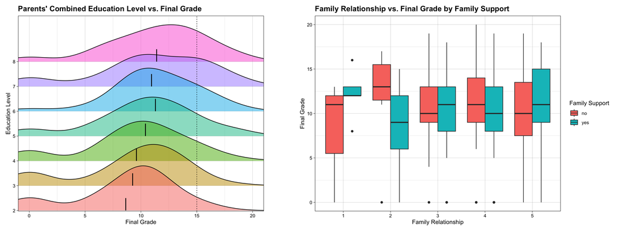

Students’ average final grades increase with a higher combined parental education level. However, there is no clear relationship between final grades and either family relationship quality or family educational support.

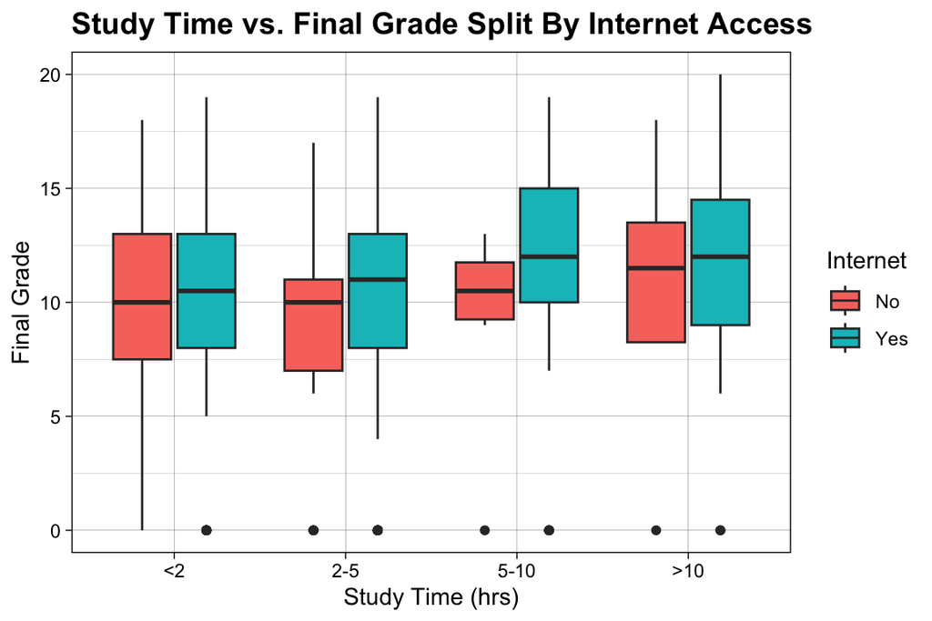

Across all buckets of student study time, average final grades are marginally better for students with internet access at home.

### Does weekly study time affect performance consistently across all terms?

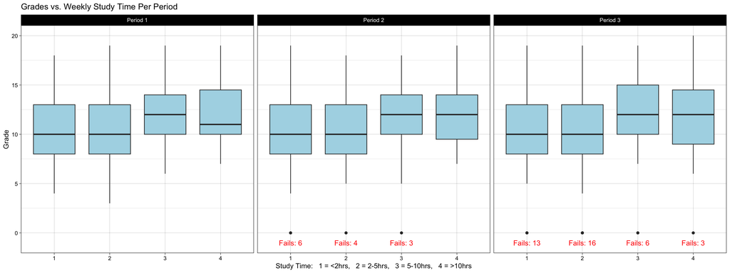

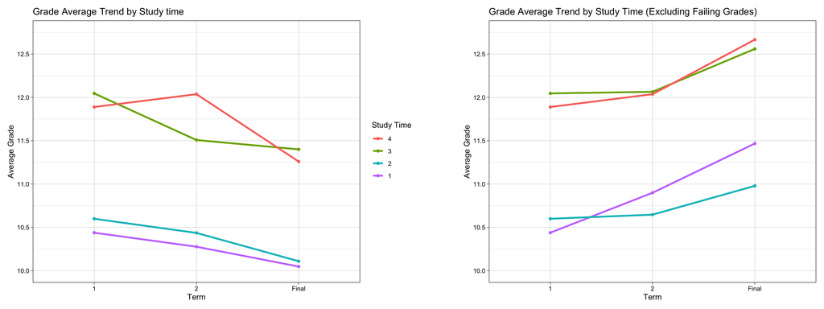

The top plot shows the distribution of student grades across different weekly study time categories for each academic period. The red text notates the number of failures for those time periods. Students in groups 3 and 4 have moderately higher mean grades across all periods, but still have failures in the final period illustrating studying alone does not prevent poor grades.

The bottom left plot shows the trending grades of students in each of the 4 study groups throughout the school year. The sharpest decline is group 4 from term 2 to the final- indicating either burnout or lack of information retention due to studying > 10 hours a week. The consistent decline across all 4 groups from term 1 to final indicated all the averages are being dragged down by failing students.

## Activities and Social Life

### Do romantic relationships affect student performance?

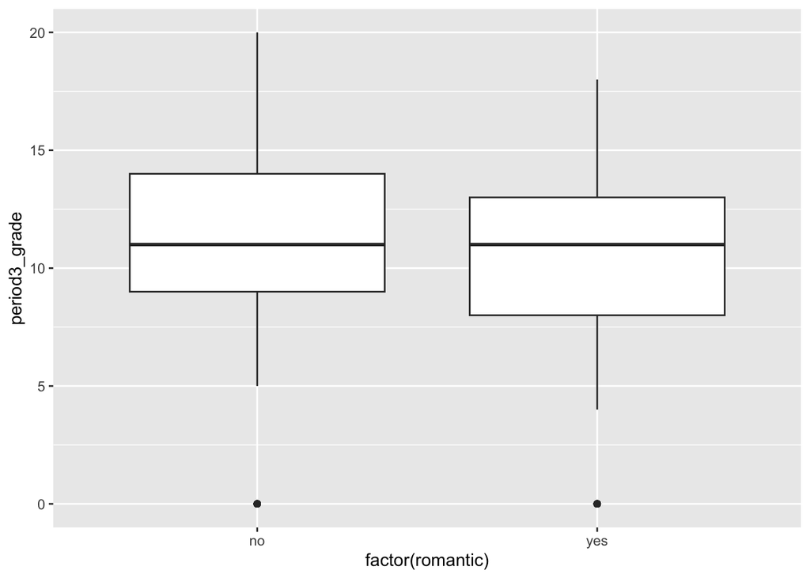

## References

> Shamim, A. (n.d.). Math-Students Performance Data [Data set]. Kaggle. https://www.kaggle.com/datasets/adilshamim8/math-students/data

> Dua, D., & Graff, C. (2017). Student Performance Data Set. UCI Machine Learning Repository. https://archive.ics.uci.edu/dataset/320/student+performance

> P. Cortez and A. Silva. Using Data Mining to Predict Secondary School Student Performance. In A. Brito and J. Teixeira (Eds.), Proceedings of 5th FUture BUsiness TEChnology Conference (FUBUTEC 2008), pp. 5-12, Porto, Portugal, April 2008, EUROSIS, ISBN 978-9077381-39-7.